# Charting an Aquaculture Future for the Caribbean

### Supply Curves

Feasible farms within each EEZ were then ranked according to: yield and profit (highest to lowest). We then examined the range of estimated yields and profits generated by farms within an EEZ, and compared the highest and lowest yield and revenue generating farms across EEZs.

$B_{EEZ} = \displaystyle\sum_{i}^{n} B_i$

$NPV_{EEZ} = \displaystyle\sum_{i}^{n} NPV_i$

Finally, national supply curves are aggregated into a single Caribbean-wide supply curve to estimate total potential cobia production and NPV for the Caribbean over a 10-year period.

$B_{Caribbean} = \displaystyle\sum_{EEZ}^{n} B_{EEZ}$

$NPV_{Caribbean} = \displaystyle\sum_{EEZ}^{n} NPV_{EEZ}$

## Production Scenarios

We apply our bioeconomic model to three production scenarios that consider different price and cost structures:

- Maximum production scenario: All suitable cells are developed (and estimate what would the price have to be)
- Current market scenario: Total production assuming current market price of cobia and costs of production
- Price/cost fluctuation scenarios: We estimate total production assuming an +/- X% annual change in the current market price and cost of production for cobia

For each scenario, we examine and compare the following:

- Total production (in terms of profit and weight) for the entire study (Caribbean) region (do economic constraints restrict things to below ecological limits (see below)…. if its below than economic constraints will keep it below ecological capacity)
- Total production (in terms of profit and weight) for each EEZ
- Range of individual farm production within EEZs (to the see potential gains of strategic spatial planning) and across EEZs (to determine the island countries with the greatest potential for offshore aquaculture development)

### Ecological Implications

Determining the aquaculture production level that a given region (in this case, an EEZ) can sustain without resulting in negative impacts to the surrounding ecosystem and environment is difficult, and will depend on the specific local oceanographic conditions and ecosystem dynamics. Although models have been developed to simulate conditions of a local area and to generate impacts of given aquaculture production scenarios on the surrounding ecosystem (CA SeaGrant study?), currently, limited empirical evidence exists to estimate the ecological carrying capacity for aquaculture production at a regional scale.

We examine the production estimates for each scenario and determine how they compare to two proxies we define as ecological capacity limits:

1. High ecological capacity limit- Ecological production limit is determined by identifying the highest aquaculture per unit area of EEZ worldwide
2. Precautionary ecological capacity limit - Aquaculture production per unit area allowed in the Gulf of Mexico by the current NOAA Fishery Management Plan (FMP) for offshore aquaculture development in the region.

# Results

## Suitability Assessment

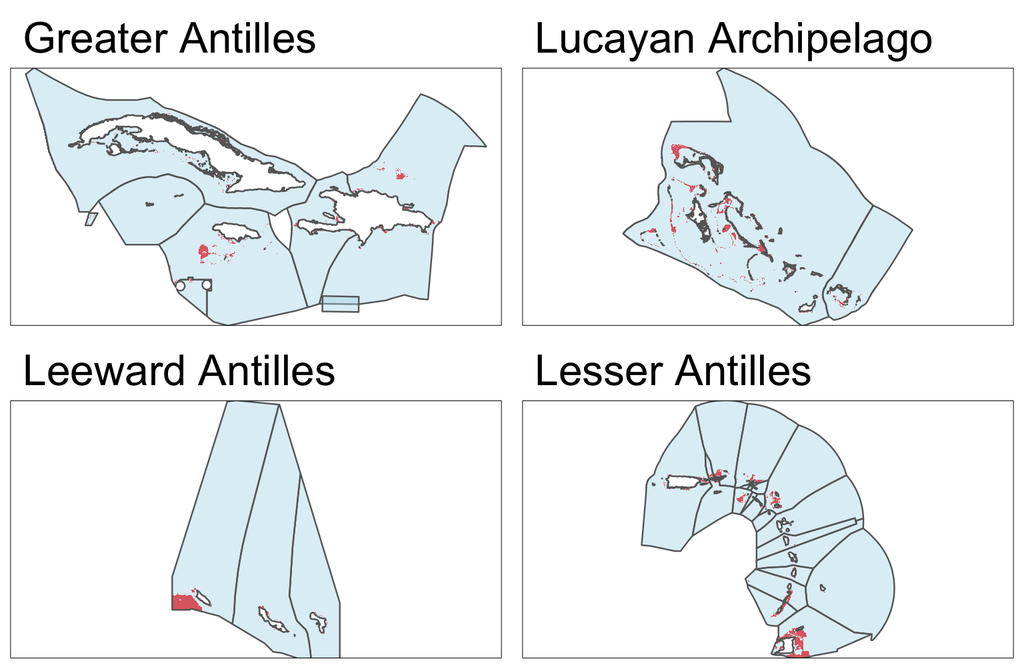

Depth was the largest constraining factor, with less than 2% of the total study area within the suitable depth range required for deployment of offshore SeaStation cages. Deep sea mining did not eliminate any areas because currently no deep sea bed mining permits have been issued in the region. However, this may be an important factor to consider in other regions or in the future in the Caribbean. .

## Sensitivity analyses

Finally, to identify the current major hurdles to the development of offshore aquaculture in the Caribbean, we determined the main factors contributing to variability of farm and EEZ level aquaculture production by performing a suite of sensitivity analyses.

Specifically, we compared the output at both the individual farm, EEZ, and regional level by running the model under a range of values for the following parameters:

- Range of suitable depths
- Costs fingerling and feed
- Cobia price
- shift in demand curve
- Risk parameters

# References

# Appendix

## removed text (just in case we need later)

Benetti, Daniel D, Mehmet R Orhun, Bruno Sardenberg, Brian O’Hanlon, Aaron Welch, Ronald Hoenig, Ian Zink, et al. 2008. “Advances in Hatchery and Grow-Out Technology of Cobia Rachycentron Canadum (Linnaeus).” *Aquaculture Research* 39 (7): 701–11. doi:10.1111/j.1365-2109.2008.01922.x.

Bhalla, Bharat. 1983. “How Corporations Should Weigh up Country Risk.” *Euromoney, June* 6672.

Brett, J. R. 1979. “10 - Environmental Factors and Growth.” In *Fish Physiology*, edited by D. J. Randall W.S. Hoar and J. R. Brett, 8:599–675. Bioenergetics and Growth. Academic Press. doi:10.1016/S1546-5098(08)60033-3.

DeCew, J., K. Baldwin, B. Celikkol, M. Chambers, D. W. Fredriksson, J. Irish, R. Langan, G. Rice, M. R. Swift, and I. Tsukrov. 2010. “Assessment of a Submerged Grid Mooring in the Gulf of Maine.” In *OCEANS 2010 MTS/IEEE SEATTLE*, 1–9. doi:10.1109/OCEANS.2010.5664025.

Fredriksson, David W., Judson DeCew, M.Robinson Swift, Igor Tsukrov, Michael D. Chambers, and Barbaros Celikkol. 2004. “The Design and Analysis of a Four-Cage Grid Mooring for Open Ocean Aquaculture.” *Aquacultural Engineering* 32 (1): 77–94. doi:10.1016/j.aquaeng.2004.05.001.

Holland, Jason. n.d. “Aquaculture on Deck: Cobia Primed for Pan-European Foodservice Launch - See More at: Https://Www.seafoodsource.com/Commentary/Aquaculture-on-Deck-Cobia-Primed-for-Pan-European-Foodservice-Launch#sthash.N9QseUoG.dpuf.”

Kapetsky, J. M., J. Aguilar-Manjarrez, and J. Jenness. 2013. “A Global Assessment of Potential for Offshore Mariculture Development from a Spatial Perspective.” *FAO Fisheries and Aquaculture Technical Paper (FAO)*.

Loverich, Gary F. 2010. “A Case Study of an Offshore SeaStation.” *Marine Technology Society Journal* 44 (3): 36–46.

McGowan Jr, Carl B., and Susan E. Moeller. 2009. “A Model for Making Foreign Direct Investment Decisions Using Real Variables for Political and Economic Risk Analysis.” *Managing Global Transitions* 7 (1): 27.

McKindsey, Christopher W., Helmut Thetmeyer, Thomas Landry, and William Silvert. 2006. “Review of Recent Carrying Capacity Models for Bivalve Culture and Recommendations for Research and Management.” *Aquaculture* 261 (2): 451–62. doi:10.1016/j.aquaculture.2006.06.044.

Sims, Neil Anthony. 2017. “Kona Blue Water Farms Case Study: Permiting, Operations, Marketing, Environmental Impacts, and Impediments to Expansion of Global Open Ocean Mariculture.” Accessed January 4.

Tidwell, James. 2012. *Aquaculture Production Systems*. John Wiley & Sons.

VLIZ. 2014. “Maritime Boundaries Geodatabase, Version 8.”

Xu, W. B., K. Q. Zhu, and Y. C. Miao. 2015. “Research of the Hydrodynamic Characteristics of Ocean Spar Sea Station.”